# Exercise 1 (20 minutes)

You practice: reading survey data, and how weights change a result. When you're done, assist some of the others …

Today we ask a new question of the same data: **do better-educated Danes trust the police more?** — and does the answer depend on whether we use **weights**?

1. Do the Setup if you haven't, then start a new R script and copy in this starter code (the same preparation we walked through on the slides):

```r
pacman::p_load(tidyverse, haven, estimatr, modelsummary)

ESS <- read_spss("ESS9e03_1.sav") %>%
  filter(cntry == "DK") %>%
  select(idno, pspwght, gndr, eduyrs, agea, psppsgva, trstlgl, trstplc) %>%
  mutate(psppsgva = zap_labels(psppsgva), # Make numeric
         trstlgl = zap_labels(trstlgl),   # Make numeric
         trstplc = zap_labels(trstplc),   # Make numeric
         pspwght = zap_labels(pspwght),   # Make numeric
         eduyrs = case_when(              # Censor education at 9 and 21 years
           eduyrs > 21 ~ 21,
           eduyrs < 9 ~ 9,
           TRUE ~ as.numeric(eduyrs)),
         gndr = as_factor(gndr)) %>%
  drop_na()
```

> **Stuck?**
> - `read_spss()` can't find the file? `ESS9e03_1.sav` must sit **in your project folder** — download it from Absalon and check the *Files* pane in RStudio.
> - Did `pacman::p_load(...)` run without red errors? Fix that first.
> - Odd results? *Session → Restart R*, then run your script from the top.
> - Still stuck? Ask (and answer!) in the [t-R-ouble forum](https://absalon.ku.dk/courses/70545/discussion_topics/563046?module_item_id=2037268) on Absalon.
2. **Now write the regression yourself:** ignoring weights for a moment, regress trust in the police (`trstplc`) on years of education (`eduyrs`) with `lm_robust()`, and read off the slope. A one-year increase in education goes with a change in police trust of (three digits; point or comma is fine).

```r
mod1 <- lm_robust(trstplc ~ eduyrs, data = ESS)

modelsummary(list("Trust in police" = mod1),
             statistic = NULL, gof_map = c("nobs", "r.squared"))
```

|  | Trust in police |
| --- | --- |
| (Intercept) | 7.530 |
| eduyrs | 0.033 |
| Num.Obs. | 1511 |
| R2 | 0.005 |

3. Still ignoring weights: is there a **gender** difference in trust in the police? Regress `trstplc` on `gndr`.

```r
mod2 <- lm_robust(trstplc ~ gndr, data = ESS)

modelsummary(list("Trust in police" = mod2),
             statistic = NULL, gof_map = c("nobs", "r.squared"))
```

|  | Trust in police |
| --- | --- |
| (Intercept) | 7.929 |
| gndrFemale | 0.159 |
| Num.Obs. | 1511 |
| R2 | 0.002 |

4. **Predict before you compute:** you are about to add survey **weights** to both models. What do you expect?
5. Rerun **both** regressions *with* `weights = pspwght` and show all four models in one table. Do the weights matter here?

```r
mod1_w <- lm_robust(trstplc ~ eduyrs, data = ESS, weights = pspwght)
mod2_w <- lm_robust(trstplc ~ gndr,   data = ESS, weights = pspwght)

modelsummary(
  list("Edu (unw.)" = mod1, "Gender (unw.)" = mod2,
       "Edu (wt.)" = mod1_w, "Gender (wt.)" = mod2_w),
  statistic = NULL, gof_map = c("nobs", "r.squared"))
```

|  | Edu (unw.) | Gender (unw.) | Edu (wt.) | Gender (wt.) |
| --- | --- | --- | --- | --- |
| (Intercept) | 7.530 | 7.929 | 7.782 | 7.801 |
| eduyrs | 0.033 |  | 0.013 |  |
| gndrFemale |  | 0.159 |  | 0.323 |
| Num.Obs. | 1511 | 1511 | 1511 | 1511 |
| R2 | 0.005 | 0.002 | 0.001 | 0.008 |

**Bonus (for the fast):** how *big* are the ESS weights? Make a histogram of `pspwght`, like the lecture's histogram of the 1000 sample slopes. Which respondents get weights well above 1, and why?

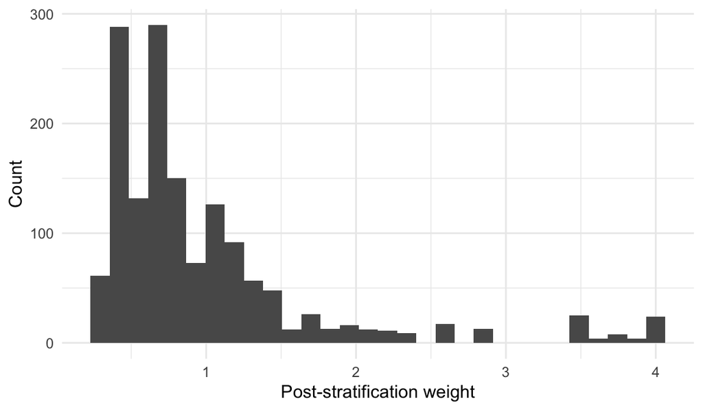

```r
ggplot(ESS, aes(x = pspwght)) +
  geom_histogram(bins = 30) +
  labs(x = "Post-stratification weight", y = "Count") +
  theme_minimal()
```